# A meta-analysis on global change drivers and the risk of infectious disease - Supplemental RMarkdown

### Parasite Taxon

Some differences among parasite taxon. Interaction model suggests only differences in responses among taxa are within biodiversity change, introduced species, and Habitat loss and change - Helminths respond more positively than bacteria and viruses to biodiversity change - Fungi respond more positively than viruses and helminths to introduced species - Viruses respond less negatively than helminths to habitat loss/change

```r
##Number of replicates
nrow(datenemy)
```

```
## [1] 2862
```

```r
mEnemy_Taxon <- rma.mv(SMDH_yi, SMDH_viC,
                  mods = ~ Enemy.type + Global.Change.Driver,
                  random = list(~1|Citation.number, ~1|ind_id),
                  data=datenemy, method = "ML")
mEnemy_TaxonIntML <- rma.mv(SMDH_yi, SMDH_viC,
                  mods = ~ Enemy.type * Global.Change.Driver,
                  random = list(~1|Citation.number, ~1|ind_id),
                  data=datenemy, method = "ML")
##very different
anova(mEnemy_Taxon, mEnemy_TaxonIntML)
```

```
##
##         df        AIC        BIC       AICc     logLik     LRT   pval
## Full    32 10309.7041 10500.0072 10310.4600 -5122.8521
## Reduced 12 10337.0757 10408.4394 10337.1866 -5156.5379 67.3716 <.0001
##                   QE
## Full    1191841.9339
## Reduced 1197179.5606
```

```r
mEnemy_TaxonInt <- rma.mv(SMDH_yi, SMDH_viC,
                      mods = ~ Enemy.type * Global.Change.Driver - 1,
                      random = list(~1|Citation.number, ~1|ind_id),
                      method = "REML", data=datenemy)
mEnemy_TaxonIntro <- robust(mEnemy_TaxonInt, cluster=Citation.number, clubSandwich=TRUE)
mEnemy_TaxonIntro
```

```
##
## Multivariate Meta-Analysis Model (k = 2827; method: REML)
##
## Variance Components:
##
##             estim    sqrt  nlvls  fixed           factor
## sigma^2.1  0.1612  0.4016    946     no  Citation.number
## sigma^2.2  1.4544  1.2060   2827     no           ind_id
##
## Test for Residual Heterogeneity:
## QE(df = 2797) = 1191841.9339, p-val < .0001
##
## Number of estimates:   2827
## Number of clusters:    946
## Estimates per cluster: 1-41 (mean: 2.99, median: 2)
##
## Test of Moderators (coefficients 1:30):¹
## F(df1 = 30, df2 = 104.37) = 3.6364, p-val < .0001
##
## Model Results:
##
##                                             estimate      se¹     tval¹     df¹
## Enemy.typeArthropod                           0.6816  0.2753    2.4756    5.59
## Enemy.typeBacteria                            0.1299  0.1584    0.8198    9.81
## Enemy.typeFungi                               0.5494  0.1682    3.2664   11.52
## Enemy.typeHelminth                            1.5903  0.3904    4.0732   12.44
## Enemy.typeProtist                             0.5088  0.3037    1.6749    3.07
## Enemy.typeVirus                               0.3943  0.1508    2.6151   10.92
## Global.Change.DriverCC                        0.0369  0.3640    0.1013   18.01
## Global.Change.DriverCP                       -0.8187  0.4058   -2.0176    3.57
## Global.Change.DriverHLC                      -0.8903  0.2917   -3.0523   11.15
## Global.Change.DriverIS                       -0.3573  0.3931   -0.9089    9.12
## Enemy.typeBacteria:Global.Change.DriverCC     0.5198  0.5293    0.9819   41.57
## Enemy.typeFungi:Global.Change.DriverCC       -0.3051  0.4273   -0.7140   32.95
## Enemy.typeHelminth:Global.Change.DriverCC    -1.1865  0.5963   -1.9899   38.02
## Enemy.typeProtist:Global.Change.DriverCC     -0.3574  0.4812   -0.7427   10.79
## Enemy.typeVirus:Global.Change.DriverCC       -0.4512  0.5207   -0.8665   41.75
## Enemy.typeBacteria:Global.Change.DriverCP     0.9597  0.4890    1.9627     5.7
## Enemy.typeFungi:Global.Change.DriverCP        0.3937  0.4501    0.8747    4.11
## Enemy.typeHelminth:Global.Change.DriverCP    -0.5476  0.5922   -0.9247    4.67
```

[output cut: 34 more lines]

```
## Enemy.typeFungi:Global.Change.DriverHLC     0.8298   -0.8947    0.7233
## Enemy.typeHelminth:Global.Change.DriverHLC  0.0455   -2.0740   -0.0232    *
## Enemy.typeProtist:Global.Change.DriverHLC   0.5841   -0.7589    1.2451
## Enemy.typeVirus:Global.Change.DriverHLC     0.0927   -0.1027    1.2655    .
## Enemy.typeBacteria:Global.Change.DriverIS   0.5544   -0.8581    1.5607
## Enemy.typeFungi:Global.Change.DriverIS      0.2133   -0.3906    1.5970
## Enemy.typeHelminth:Global.Change.DriverIS   0.0464   -2.6037   -0.0237    *
## Enemy.typeProtist:Global.Change.DriverIS    0.9276   -1.8890    1.7384
## Enemy.typeVirus:Global.Change.DriverIS      0.9314   -0.8652    0.9408
##
## ---
## Signif. codes:  0 '***' 0.001 '**' 0.01 '*' 0.05 '.' 0.1 ' ' 1
##
## 1) results based on cluster-robust inference (var-cov estimator: CR2,
##    approx t/F-tests and confidence intervals, df: Satterthwaite approx)
```

```
## Global.Change.Driver = BC:
##  contrast             estimate     SE  df z.ratio p.value
##  Arthropod - Bacteria  0.55173 0.3177 Inf   1.737  0.5072
##  Arthropod - Fungi     0.13225 0.3226 Inf   0.410  0.9985
##  Arthropod - Helminth -0.90864 0.4777 Inf  -1.902  0.4008
##  Arthropod - Protist   0.17286 0.4100 Inf   0.422  0.9983
##  Arthropod - Virus     0.28734 0.3139 Inf   0.915  0.9427
##  Bacteria - Fungi     -0.41947 0.2311 Inf  -1.815  0.4557
##  Bacteria - Helminth  -1.46037 0.3981 Inf  -3.668  0.0033
##  Bacteria - Protist   -0.37886 0.3047 Inf  -1.244  0.8153
##  Bacteria - Virus     -0.26438 0.2129 Inf  -1.242  0.8162
##  Fungi - Helminth     -1.04089 0.4251 Inf  -2.449  0.1398
##  Fungi - Protist       0.04061 0.3472 Inf   0.117  1.0000
##  Fungi - Virus         0.15509 0.2259 Inf   0.687  0.9835
##  Helminth - Protist    1.08150 0.5236 Inf   2.066  0.3055
##  Helminth - Virus      1.19598 0.4043 Inf   2.958  0.0365
##  Protist - Virus       0.11448 0.3247 Inf   0.353  0.9993
##
## Global.Change.Driver = CC:
##  contrast             estimate     SE  df z.ratio p.value
##  Arthropod - Bacteria  0.03195 0.4234 Inf   0.075  1.0000
##  Arthropod - Fungi     0.43734 0.2801 Inf   1.561  0.6242
##  Arthropod - Helminth  0.27785 0.3568 Inf   0.779  0.9712
##  Arthropod - Protist   0.53022 0.2519 Inf   2.105  0.2847
##  Arthropod - Virus     0.73858 0.4155 Inf   1.778  0.4803
##  Bacteria - Fungi      0.40539 0.3805 Inf   1.065  0.8951
##  Bacteria - Helminth   0.24590 0.4419 Inf   0.556  0.9937
##  Bacteria - Protist    0.49827 0.3574 Inf   1.394  0.7307
##  Bacteria - Virus      0.70664 0.4879 Inf   1.448  0.6973
##  Fungi - Helminth     -0.15949 0.3074 Inf  -0.519  0.9955
##  Fungi - Protist       0.09288 0.1687 Inf   0.550  0.9940
##  Fungi - Virus         0.30124 0.3712 Inf   0.812  0.9655
##  Helminth - Protist    0.25237 0.2817 Inf   0.896  0.9476
##  Helminth - Virus      0.46073 0.4343 Inf   1.061  0.8969
##  Protist - Virus       0.20836 0.3489 Inf   0.597  0.9912
##
## Global.Change.Driver = CP:
##  contrast             estimate     SE  df z.ratio p.value
##  Arthropod - Bacteria -0.40796 0.3717 Inf  -1.097  0.8826
##  Arthropod - Fungi    -0.26145 0.3142 Inf  -0.832  0.9616
```

[output cut: 36 more lines]

```
##  Arthropod - Helminth  0.40506 0.3831 Inf   1.057  0.8982
##  Arthropod - Protist   0.24814 0.6946 Inf   0.357  0.9992
##  Arthropod - Virus     0.24951 0.3004 Inf   0.831  0.9619
##  Bacteria - Fungi     -0.67139 0.4347 Inf  -1.544  0.6353
##  Bacteria - Helminth   0.20462 0.4809 Inf   0.426  0.9982
##  Bacteria - Protist    0.04770 0.7530 Inf   0.063  1.0000
##  Bacteria - Virus      0.04907 0.4177 Inf   0.117  1.0000
##  Fungi - Helminth      0.87601 0.3027 Inf   2.894  0.0440
##  Fungi - Protist       0.71909 0.6547 Inf   1.098  0.8822
##  Fungi - Virus         0.72046 0.1466 Inf   4.913  <.0001
##  Helminth - Protist   -0.15692 0.6868 Inf  -0.228  0.9999
##  Helminth - Virus     -0.15555 0.2800 Inf  -0.555  0.9938
##  Protist - Virus       0.00137 0.6439 Inf   0.002  1.0000
##
## P value adjustment: tukey method for comparing a family of 6 estimates
```

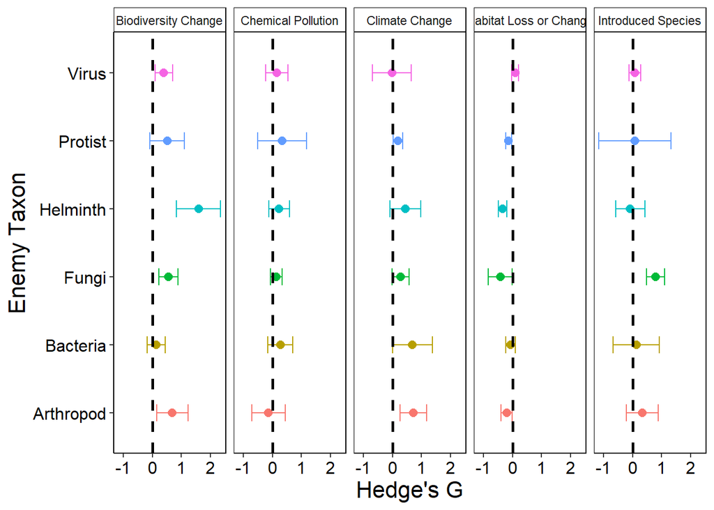

```r
##Set up emmeans reference grid
mEnemyg <- qdrg(object = mEnemy_TaxonIntro, data = datenemy)

mEnemygem <- emmeans(mEnemyg, ~ Enemy.type|Global.Change.Driver)

#
pairs((mEnemygem))
```

### Vector

No difference between vectors and non-vectors

```r
##Number of replicates
nrow(vecdat)
```

```
## [1] 2167
```

```r
mVector <- rma.mv(SMDH_yi, SMDH_viC,
                  mods = ~ Vector + Global.Change.Driver,
                  random = list(~1|Citation.number, ~1|ind_id),
                  data=vecdat, method = "ML")
mVectorInt <- rma.mv(SMDH_yi, SMDH_viC,
                  mods = ~ Vector * Global.Change.Driver,
                  random = list(~1|Citation.number, ~1|ind_id),
                  data=vecdat, method = "ML")
## different
anova(mVector, mVectorInt)
```

```
##
##         df       AIC       BIC      AICc     logLik    LRT   pval           QE
## Full     8 8001.4211 8046.7359 8001.4889 -3992.7105               1296447.0690
## Reduced  6 7998.9214 8032.9075 7998.9610 -3993.4607 1.5004 0.4723 1299047.4652
```

```r
mVectorInt <- rma.mv(SMDH_yi, SMDH_viC,
                      mods = ~ Vector + Global.Change.Driver - 1,
                      random = list(~1|Citation.number, ~1|ind_id), data=vecdat)
mVectorIntro <- robust(mVectorInt, cluster=Citation.number, clubSandwich=TRUE)
mVectorIntro
```

```
##
## Multivariate Meta-Analysis Model (k = 2131; method: REML)
##
## Variance Components:
##
##             estim    sqrt  nlvls  fixed           factor
## sigma^2.1  0.0863  0.2937    792     no  Citation.number
## sigma^2.2  1.7852  1.3361   2131     no           ind_id
##
## Test for Residual Heterogeneity:
## QE(df = 2127) = 1299047.4652, p-val < .0001
##
## Number of estimates:   2131
## Number of clusters:    792
## Estimates per cluster: 1-40 (mean: 2.69, median: 1)
##
## Test of Moderators (coefficients 1:4):¹
## F(df1 = 4, df2 = 154.18) = 14.9738, p-val < .0001
##
## Model Results:
##
##                          estimate      se¹     tval¹      df¹    pval¹
## VectorNo                   0.3583  0.0912    3.9284   123.68   0.0001
## VectorYes                  0.3805  0.1305    2.9162    55.68   0.0051
## Global.Change.DriverHLC   -0.5520  0.0982   -5.6195   189.79   <.0001
## Global.Change.DriverIS     0.1383  0.1392    0.9937   120.71   0.3224
##                            ci.lb¹    ci.ub¹
## VectorNo                  0.1778    0.5388   ***
## VectorYes                 0.1191    0.6420    **
## Global.Change.DriverHLC  -0.7458   -0.3583   ***
## Global.Change.DriverIS   -0.1373    0.4140
##
## ---
## Signif. codes:  0 '***' 0.001 '**' 0.01 '*' 0.05 '.' 0.1 ' ' 1
##
## 1) results based on cluster-robust inference (var-cov estimator: CR2,
##    approx t/F-tests and confidence intervals, df: Satterthwaite approx)
```

```r
##Set up emmeans reference grid
mVectorg <- qdrg(object = mVectorIntro, data = vecdat)

mVectorgem <- emmeans(mVectorg, ~ Vector)

#
pairs((mVectorgem))
```

```
##  contrast estimate    SE  df z.ratio p.value
##  No - Yes  -0.0223 0.119 Inf  -0.187  0.8516
##
## Results are averaged over the levels of: Global.Change.Driver
```

### Vector-borne

No generalizable differences between vector-borne and non-vector-borne diseases, but within biodiversity change and Introduced Species, there are differences. In biodiversity change, vector-borne diseases respond significantly stronger (positive) to biodiversity change than non-vector-borne diseases. This is consistent with previous work from Dave Civitello, suggesting that dilution effect is more prominent in vector-borne diseases. In Introduced Species, non-vector-borne diseases respond significantly stronger (positive) to introduced species than vector-borne diseases.

```r
##Number of replicates
nrow(vecbordat)
```

```
## [1] 2847
```

```r
mVectorBorne <- rma.mv(SMDH_yi, SMDH_viC,
                  mods = ~ Vector.borne + Global.Change.Driver,
                  random = list(~1|Citation.number, ~1|ind_id),
                  data=vecbordat, method = "ML")
mVectorBorneIntML <- rma.mv(SMDH_yi, SMDH_viC,
                  mods = ~ Vector.borne * Global.Change.Driver,
                  random = list(~1|Citation.number, ~1|ind_id),
                  data=vecbordat, method = "ML")
anova(mVectorBorne, mVectorBorneIntML)
```

```
##
##         df        AIC        BIC       AICc     logLik     LRT   pval
## Full    12 10271.1377 10342.4332 10271.2492 -5123.5688
## Reduced  8 10285.4164 10332.9468 10285.4678 -5134.7082 22.2787 0.0002
##                   QE
## Full    1300896.6682
## Reduced 1301325.8655
```

```r
mVectorBorneInt <- rma.mv(SMDH_yi, SMDH_viC,
                      mods = ~ Vector.borne * Global.Change.Driver - 1,
                      random = list(~1|Citation.number, ~1|ind_id), data=vecbordat)
mVectorBorneIntro <- robust(mVectorBorneInt, cluster=Citation.number, clubSandwich=TRUE)
mVectorBorneIntro
```

```
##
## Multivariate Meta-Analysis Model (k = 2811; method: REML)
##
## Variance Components:
##
##             estim    sqrt  nlvls  fixed           factor
## sigma^2.1  0.1886  0.4343    965     no  Citation.number
## sigma^2.2  1.4590  1.2079   2811     no           ind_id
##
## Test for Residual Heterogeneity:
## QE(df = 2801) = 1300896.6682, p-val < .0001
##
## Number of estimates:   2811
## Number of clusters:    965
## Estimates per cluster: 1-41 (mean: 2.91, median: 2)
##
## Test of Moderators (coefficients 1:10):¹
## F(df1 = 10, df2 = 149.99) = 10.2159, p-val < .0001
##
## Model Results:
##
##                                          estimate      se¹     tval¹     df¹
## Vector.borneNo                             0.5462  0.1122    4.8675    28.1
## Vector.borneYes                            1.1419  0.2663    4.2887   21.75
## Global.Change.DriverCC                    -0.1081  0.1622   -0.6662   71.11
## Global.Change.DriverCP                    -0.4094  0.1415   -2.8943   63.68
## Global.Change.DriverHLC                   -0.7421  0.1199   -6.1899   37.89
## Global.Change.DriverIS                     0.0911  0.1756    0.5187   67.73
## Vector.borneYes:Global.Change.DriverCC    -0.8430  0.3122   -2.7004   81.38
## Vector.borneYes:Global.Change.DriverCP    -0.3861  0.3249   -1.1884    42.1
## Vector.borneYes:Global.Change.DriverHLC   -0.6038  0.2865   -2.1071   51.45
## Vector.borneYes:Global.Change.DriverIS    -1.4044  0.4150   -3.3837   31.81
##                                            pval¹    ci.lb¹    ci.ub¹
## Vector.borneNo                           <.0001    0.3164    0.7760   ***
## Vector.borneYes                          0.0003    0.5893    1.6944   ***
## Global.Change.DriverCC                   0.5074   -0.4315    0.2153
## Global.Change.DriverCP                   0.0052   -0.6921   -0.1268    **
## Global.Change.DriverHLC                  <.0001   -0.9848   -0.4993   ***
## Global.Change.DriverIS                   0.6056   -0.2594    0.4416
## Vector.borneYes:Global.Change.DriverCC   0.0084   -1.4641   -0.2219    **
## Vector.borneYes:Global.Change.DriverCP   0.2413   -1.0418    0.2695
## Vector.borneYes:Global.Change.DriverHLC  0.0400   -1.1789   -0.0286     *
## Vector.borneYes:Global.Change.DriverIS   0.0019   -2.2500   -0.5588    **
##
## ---
## Signif. codes:  0 '***' 0.001 '**' 0.01 '*' 0.05 '.' 0.1 ' ' 1
##
## 1) results based on cluster-robust inference (var-cov estimator: CR2,
##    approx t/F-tests and confidence intervals, df: Satterthwaite approx)
```

```
## Global.Change.Driver = BC:
##  contrast estimate     SE  df z.ratio p.value
##  No - Yes -0.59571 0.2706 Inf  -2.201  0.0277
##
## Global.Change.Driver = CC:
##  contrast estimate     SE  df z.ratio p.value
##  No - Yes  0.24732 0.1557 Inf   1.589  0.1121
##
## Global.Change.Driver = CP:
##  contrast estimate     SE  df z.ratio p.value
##  No - Yes -0.20959 0.1800 Inf  -1.165  0.2442
##
## Global.Change.Driver = HLC:
##  contrast estimate     SE  df z.ratio p.value
##  No - Yes  0.00806 0.0943 Inf   0.086  0.9318
##
## Global.Change.Driver = IS:
##  contrast estimate     SE  df z.ratio p.value
##  No - Yes  0.80866 0.3147 Inf   2.570  0.0102
```

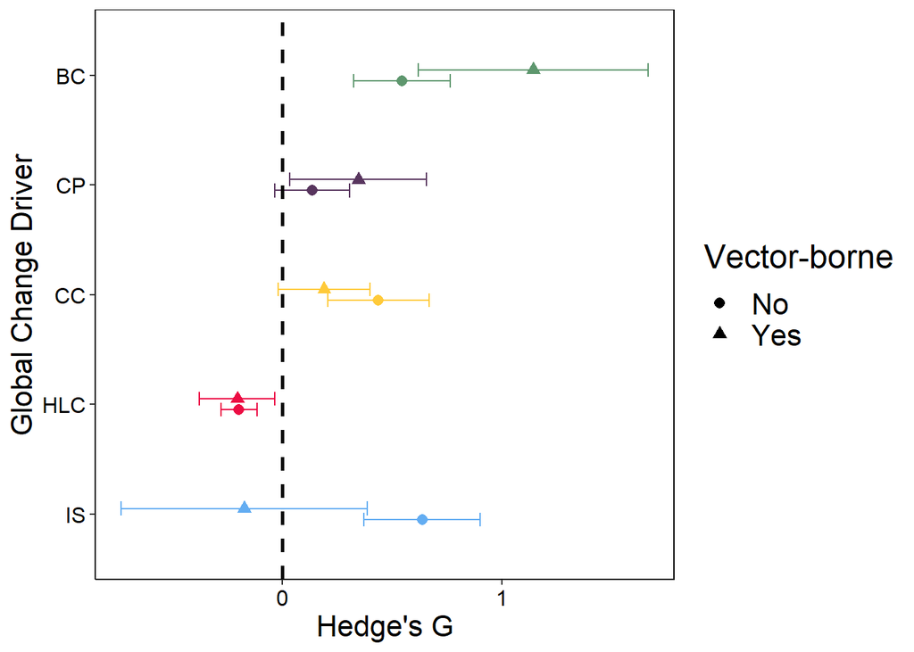

```r
##Set up emmeans reference grid
mVectorBg <- qdrg(object = mVectorBorneIntro, data = vecbordat)

mVectorBgem <- emmeans(mVectorBg, ~ Vector.borne|Global.Change.Driver)

#Only difference is in BC and IS
pairs((mVectorBgem))
```

### Ecto- v. Endoparasites

```r
##Number of replicates
nrow(ectodat)
```

```
## [1] 2913
```

```r
mEctoparasite <- rma.mv(SMDH_yi, SMDH_viC,
                  mods = ~ Ectoparasite + Global.Change.Driver,
                  random = list(~1|Citation.number, ~1|ind_id),
                  data=ectodat, method = "ML")
mEctoparasiteIntML <- rma.mv(SMDH_yi, SMDH_viC,
                  mods = ~ Ectoparasite * Global.Change.Driver,
                  random = list(~1|Citation.number, ~1|ind_id),
                  data=ectodat, method = "ML")
anova(mEctoparasite, mEctoparasiteIntML)
```

```
##
##         df        AIC        BIC       AICc     logLik     LRT   pval
## Full    12 10455.7689 10527.3430 10455.8779 -5215.8845
## Reduced  8 10468.3759 10516.0920 10468.4261 -5226.1880 20.6070 0.0004
##                   QE
## Full    1247538.4331
## Reduced 1298354.0917
```

```r
mEctoparasiteInt <- rma.mv(SMDH_yi, SMDH_viC,
                      mods = ~ Ectoparasite * Global.Change.Driver - 1,
                      random = list(~1|Citation.number, ~1|ind_id), data=ectodat)
mEctoparasiteIntro <- robust(mEctoparasiteInt, cluster=Citation.number, clubSandwich=TRUE)
mEctoparasiteIntro
```

```
##
## Multivariate Meta-Analysis Model (k = 2877; method: REML)
##
## Variance Components:
##
##             estim    sqrt  nlvls  fixed           factor
## sigma^2.1  0.1842  0.4292    978     no  Citation.number
## sigma^2.2  1.4279  1.1949   2877     no           ind_id
##
## Test for Residual Heterogeneity:
## QE(df = 2867) = 1247538.4331, p-val < .0001
##
## Number of estimates:   2877
## Number of clusters:    978
## Estimates per cluster: 1-41 (mean: 2.94, median: 2)
##
## Test of Moderators (coefficients 1:10):¹
## F(df1 = 10, df2 = 183.06) = 14.0618, p-val < .0001
##
## Model Results:
##
##                                          estimate      se¹     tval¹     df¹
## EctoparasiteNo                             0.9081  0.1930    4.7040   36.57
## EctoparasiteYes                            0.5112  0.1634    3.1283   13.84
## Global.Change.DriverCC                    -0.5637  0.2208   -2.5529   86.86
## Global.Change.DriverCP                    -0.6172  0.2269   -2.7201   80.06
## Global.Change.DriverHLC                   -1.1114  0.1965   -5.6568   47.45
## Global.Change.DriverIS                    -0.8101  0.2643   -3.0655   78.28
## EctoparasiteYes:Global.Change.DriverCC     0.3995  0.3070    1.3012    78.9
## EctoparasiteYes:Global.Change.DriverCP     0.1624  0.2944    0.5515   75.84
## EctoparasiteYes:Global.Change.DriverHLC    0.4691  0.3208    1.4624   58.07
## EctoparasiteYes:Global.Change.DriverIS     1.0671  0.3126    3.4138   65.81
##                                            pval¹    ci.lb¹    ci.ub¹
## EctoparasiteNo                           <.0001    0.5168    1.2994   ***
## EctoparasiteYes                          0.0075    0.1603    0.8621    **
## Global.Change.DriverCC                   0.0124   -1.0026   -0.1248     *
## Global.Change.DriverCP                   0.0080   -1.0687   -0.1656    **
## Global.Change.DriverHLC                  <.0001   -1.5066   -0.7163   ***
## Global.Change.DriverIS                   0.0030   -1.3361   -0.2840    **
## EctoparasiteYes:Global.Change.DriverCC   0.1970   -0.2116    1.0105
## EctoparasiteYes:Global.Change.DriverCP   0.5829   -0.4241    0.7488
## EctoparasiteYes:Global.Change.DriverHLC  0.1490   -0.1730    1.1112
## EctoparasiteYes:Global.Change.DriverIS   0.0011    0.4430    1.6912    **
##
## ---
## Signif. codes:  0 '***' 0.001 '**' 0.01 '*' 0.05 '.' 0.1 ' ' 1
##
## 1) results based on cluster-robust inference (var-cov estimator: CR2,
##    approx t/F-tests and confidence intervals, df: Satterthwaite approx)
```

```
## Global.Change.Driver = BC:
##  contrast estimate    SE  df z.ratio p.value
##  No - Yes   0.3969 0.253 Inf   1.569  0.1166
##
## Global.Change.Driver = CC:
##  contrast estimate    SE  df z.ratio p.value
##  No - Yes  -0.0026 0.174 Inf  -0.015  0.9881
##
## Global.Change.Driver = CP:
##  contrast estimate    SE  df z.ratio p.value
##  No - Yes   0.2345 0.152 Inf   1.546  0.1220
##
## Global.Change.Driver = HLC:
##  contrast estimate    SE  df z.ratio p.value
##  No - Yes  -0.0723 0.197 Inf  -0.366  0.7142
##
## Global.Change.Driver = IS:
##  contrast estimate    SE  df z.ratio p.value
##  No - Yes  -0.6702 0.184 Inf  -3.649  0.0003
```

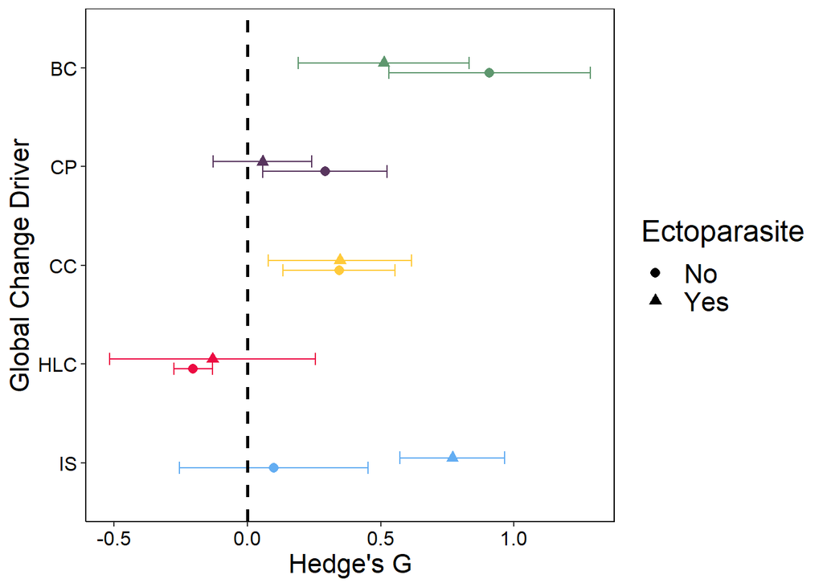

```r
##Set up emmeans reference grid
mEctoparasiteBg <- qdrg(object = mEctoparasiteIntro, data = ectodat)

mEctoparasiteBgem <- emmeans(mEctoparasiteBg, ~ Ectoparasite|Global.Change.Driver)

#Only difference is in IS
pairs((mEctoparasiteBgem))
```